# 비지도학습이란?

##### 지도학습과는 달리 정답(Y)이 없는 데이터를 가지고 학습하는 것이다

##### 비지도학습의 목표는 해당 데이터의 패턴, 특성 및 구조를 스스로 파악하여 이를 통해 데이터가 어떻게 구성되었는지 새로운 규칙성을 알아내는 과정

##### 비지도학습은 크게 군집분석과 차원축소로 나눌 수 있다

### Clustering - 군집분석

##### 군집분석은 비지도학습(unsupervised learning)의 일종으로 유사한 데이터끼리 그룹화를 시키는 학습모델을 말한다. 각 데이터의 유사성을 측정하여, 유사성이 높은 집단끼리 분류하고 군집간에 상이성을 규명하는 방법이다

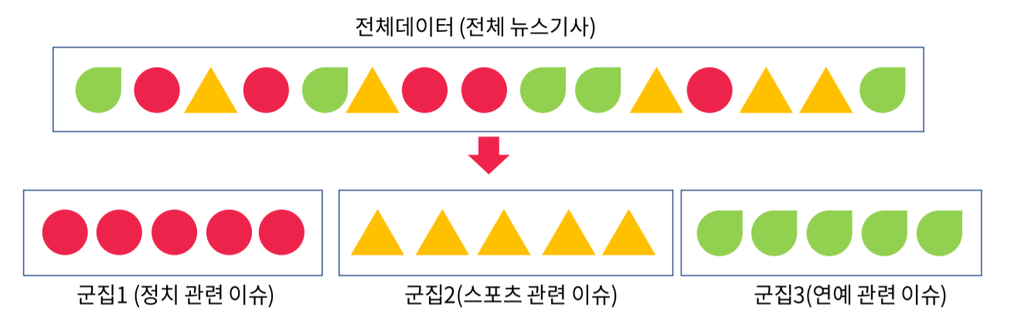

```python
from IPython.display import Image
image_path = 'C:/Users/jaemi/OneDrive/Desktop/비지도학습/kmeans/img1.png'
Image(filename=image_path, width=800)
```

##### 위의 그림을 보면 raw data에는 여러가지 종류가 섞여있다. 섞여있는 raw data를 군집분석을 통해 서로 다른 특성을 가진 군집으로 분류한다. 이때, 분류문제와는 다르게 target Y가 존재하지 않는다. 그렇기에 학습과정에 있어서 정답을 맞출 기준표가 없는 것이다.

##### 위의 그림은 기사에 대한 군집분석을 보여준다. 각 군집은 이슈별로 정리된 결과를 도출했다. 이처럼 군집분석은 raw data에서 segmentation을 통해 insight를 도출하고, 이를 특정 활용하여 마케팅/특정 프로모션등으로 활용할 수 있다. 물론 군집 별 추가 분석을 수행하여 새로운 더 심화적인 insight를 도출할 수도 있다.

##### 이러한Clustering의 종류로는 대표적으로

##### -K-means clustering : 데이터를 사용자가 지정한 k개의 군집으로 나눈다.

##### -계층적 군집분석(Hierarchical clustering) : 나무 모양의 계층적 구조를 형성하여 군집분석을 수행한다.

##### -DBSCAN : k개를 설정할 필요없이 인근에 있는 데이터를 따라가며 군집화 할 수 있다.

##### 와 같은 종류들이 있다

### Hierarchical clustering(계층적 군집분석)

##### Hierarchical clustering은 개체들을 가까운 집단부터 순차적이고 계층적으로 차근차근 묶어나가는 방식이다. 이러한 방식으로 군집이 형성되기에 유사한 개체들이 결합되는 dendogram을 통해서 시각화가 가능하고, 계층적 구조로 인해 사전에 군집의 개수를 정하지 않아도 수행이 가능하다.

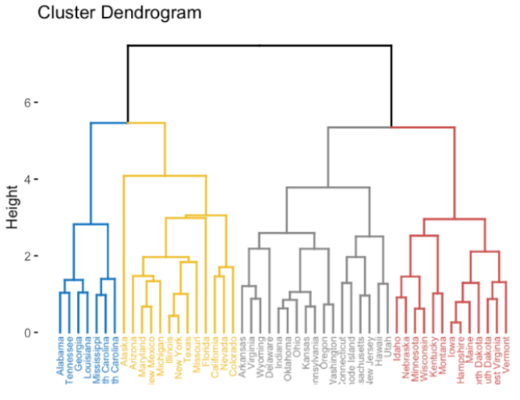

```python
image_path = 'C:/Users/jaemi/OneDrive/Desktop/비지도학습/hierarchy/img1.png'
Image(filename=image_path, width=700)
```

##### 위 그림은 계층적 군집분석 결과를 tree형태로 시각화 한 덴드로그램의 한 예시이다.

##### Hierarchical clustering이 학습되는 과정은 아래와 같다.

##### 1. 모든 개체들 사이의 거리에 대한 유사도 행렬 계산

##### 2. 거리가 인접한 관측치끼리 cluster 형성

##### 3. 유사도 행렬 업데이트

##### 아래의 예시를 봐보자.

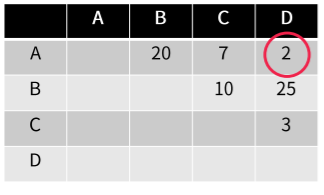

```python
image_path = 'C:/Users/jaemi/OneDrive/Desktop/비지도학습/hierarchy/img2.png'
Image(filename=image_path, width=400)
```

먼저 처음의 유사도 행렬이 만들어졌다. 이때 A와 가장 거리상 유사한 점은 D이다. 이 두 관측치를 한 cluster로 묶는다.

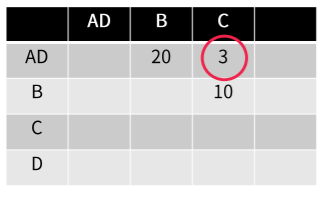

```python
image_path = 'C:/Users/jaemi/OneDrive/Desktop/비지도학습/hierarchy/img3.png'
Image(filename=image_path, width=400)
```

##### A와 D가 한 cluster로 묶였다. 그러면 유사도 행렬은 AD로 업데이트 된다. 이제 업데이트된 유사도 행렬에서 가장 가까운 관측치는 C이다. 이 C를 다시 clustering한다. 이것을 계속 반복한다

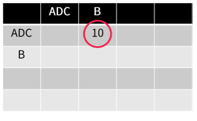

```python
image_path = 'C:/Users/jaemi/OneDrive/Desktop/비지도학습/hierarchy/img4.png'
Image(filename=image_path, width=400)
```

##### 그리고 남은 관측치들이 모두 클러스터링이 되면 학습을 종료한다.

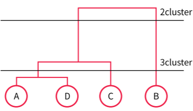

```python
image_path = 'C:/Users/jaemi/OneDrive/Desktop/비지도학습/hierarchy/img5.png'
Image(filename=image_path, width=500)
```

##### 최종적으로 도출된 결과는 위의 Tree형태와 같다. 이때, 군집을 2개 형성한다면, ADC/B와 같이 나뉠 것이고, 군집을 3개 형성한다면, AD/C/B로 나뉠 것이다. 이것은 거리를 기반한 유사도로 만들어졌다.

##### Hierarchical clustering에도 K-means/K-medoids처럼 거리를 선택할 수 있다. 가장 가까운 Min, 가장 멀리 떨어진 Max, 평균, 중앙점 비교를 모두 유사도 행렬상에서 clustering간의 거리로 활용할 수 있다.

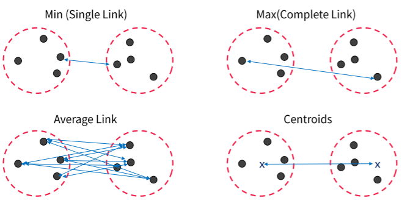

```python
image_path = 'C:/Users/jaemi/OneDrive/Desktop/비지도학습/hierarchy/img6.png'
Image(filename=image_path, width=800)
```

##### 그리고 추가적으로 Ward's method가 있다. Ward's method는 두 개의 클러스터가 병합되었을 때 증가되는 변동성의 양을 기준으로 하는 방법이다. 수식으로 표현하면 아래와 같다.

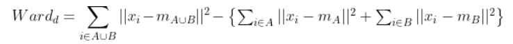

```python
image_path = 'C:/Users/jaemi/OneDrive/사진/스크린샷/수식1.png'
Image(filename=image_path, width=700)
```

##### 아래의 이미지를 보자. 왼쪽 예시는 두 개의 클러스터가 상대적으로 더 떨어져있는 예시이다. 오른쪽에 비해서 변동성이 큰 것이다. 그렇기에 ward distance는 더 크다. 반면 오른쪽은 더 가깝기에 ward distance는 더 작게 표현된다.

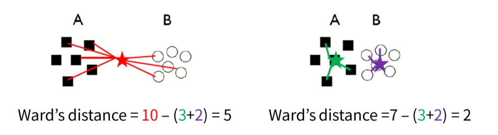

```python
image_path = 'C:/Users/jaemi/OneDrive/Desktop/비지도학습/hierarchy/img7.png'
Image(filename=image_path, width=900)
```

### hierarchy clustering 파이썬 실습

##### Hierarchical Clustering은 Tree기반의 모델이다.

##### 2차원의 데이터의 경우를 생각해보자. 2차원 데이터는 좌표로 가시적으로 군집을 시각화시킬수 있지만,

##### 3차원은 보기가 힘들어진다. 그리고 4차원이 넘어서면, 시각화가 거의 불가능해진다.

##### Hierarchical clustering은 이러한 3차원 이상의 군집에서도 dendogram을 통해 직관적인 cluster 형성이 가능하다는 장점이 있다.

##### 가장 기본적인 Hierarchical Clustering을 먼저 확인해보자.

```python
# 기본 library
import matplotlib.pyplot as plt
import pandas as pd
import numpy as np
```

```python
# 실습데이터 형성
X = np.array([[5,3],
    [10,15],
    [15,12],
    [24,10],
    [30,30],
    [85,70],
    [71,80],
    [60,78],
    [70,55],
    [80,91],])
```

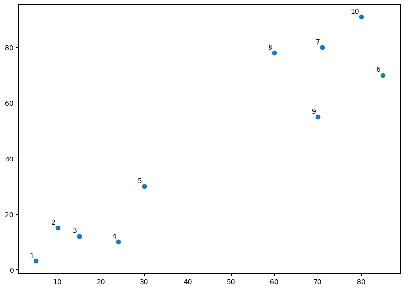

```python
import matplotlib.pyplot as plt

labels = range(1, 11)
plt.figure(figsize=(10, 7))
plt.subplots_adjust(bottom=0.1)
plt.scatter(X[:,0],X[:,1], label='True Position')

for label, x, y in zip(labels, X[:, 0], X[:, 1]):
    plt.annotate(
        label,
        xy=(x, y), xytext=(-3, 3),
        textcoords='offset points', ha='right', va='bottom')
plt.show()
```

##### 이를 통해서 1번 점부터 10번 점까지 반복해서 표기를 한 것이다.

```python
from scipy.cluster.hierarchy import dendrogram, linkage
from matplotlib import pyplot as plt

linked = linkage(X, 'single')
```

##### hierarchical clustering은 scipy.cluster.hierarchy 패키지를 통해서 구현할 수 있다.

##### 그리고 hierarchical clustering의 특성 중 하나인 clustering을 dendogram으로 표현하기 위해서 dendogram 또한 함께 import를 하였다.

##### linkage함수에 인수로 'single'을0 넣었는데 이는 거리를 계산하는 method 알고리즘의 차이이다.

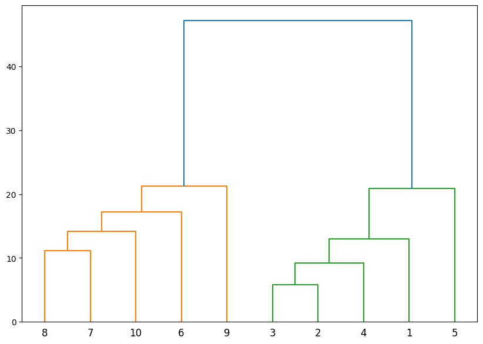

```python
labelList = range(1, 11)

plt.figure(figsize=(10, 7))
dendrogram(linked,
            orientation='top',
            labels=labelList,
            distance_sort='descending',
            show_leaf_counts=True)
plt.show()
```

##### 학습된 결과를 dendogram을 통해서 시각화하면 위와 같다.

##### leaf node까지 표현되어 10개의 cluster를 만들수 있긴 하지만, 여기서 합당한 cluster 개수는 2로 보인다.

##### 이제 실제 데이터를 가져와서 실습해보자.

```python
customer_data=pd.read_csv('C:/Users/jaemi/Downloads/shopping-data.csv')
customer_data.head()
```

|  | CustomerID | Genre | Age | Annual Income (k$) | Spending Score (1-100) |
| --- | --- | --- | --- | --- | --- |
| 0 | 1 | Male | 19 | 15 | 39 |
| 1 | 2 | Male | 21 | 15 | 81 |
| 2 | 3 | Female | 20 | 16 | 6 |
| 3 | 4 | Female | 23 | 16 | 77 |
| 4 | 5 | Female | 31 | 17 | 40 |

##### 데이터는 캐글에서 가져왔고, 데이터의 형태는 위와 같다.

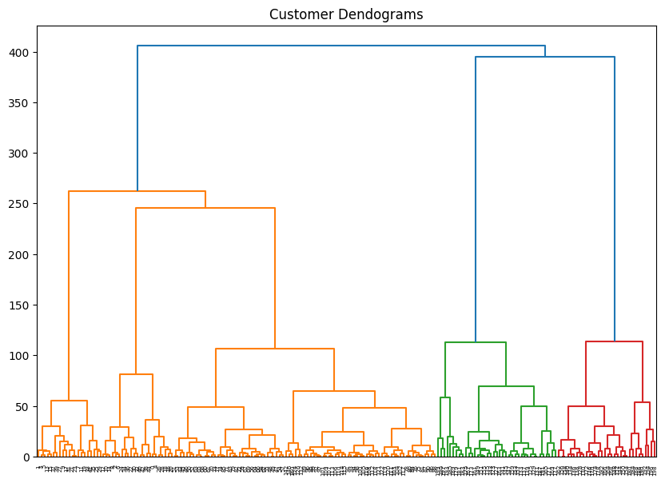

```python
data = customer_data.iloc[:, 3:5].values

import scipy.cluster.hierarchy as shc

plt.figure(figsize=(10, 7))
plt.title("Customer Dendograms")
dend = shc.dendrogram(shc.linkage(data, method='ward'))
```

##### 이번에는 ward method 알고리즘을 통해서 Hierarchical Clustering을 진행하였다.

##### 위에서 언급했듯이 거리계산방법의 차이이다.